*Note: Notes*

# Aspects of motivic cohomology

Matthew Morrow, IAS/PCMI GSS 2021

D. Zack Garza

University of Georgia  
[email protected]

Last updated: 2021-07-27

# 1 Matthew Morrow, Talk 1 (Thursday, July 15)

## 1.1 Intro

**Abstract**:

> Motivic cohomology offers, at least in certain situations, a geometric refinement of algebraic K-theory or its variants (G-theory, KH-theory, étale K-theory, $\cdots$). We will overview some aspects of the subject, ranging from the original cycle complexes of Bloch, through Voevodsky’s work over fields, to more recent p-adic developments in the arithmetic context where perfectoid and prismatic techniques appear.

**References/Background**:

- Algebraic geometry, sheaf theory, cohomology.
  - Comfort with derived techniques such as descent and the cotangent complex would be helpful.
  - Casual familiarity with K-theory, cyclic homology, and their variants would be motivational.
  - Infinity-categories and spectra will appear, though probably not in a very essential way.
- [Lecture Notes](https://www.ias.edu/sites/default/files/Morrow%20lectures%201%2B2.pdf)

Some things we’ve already seen that will be useful:

- Motivic complexes
- Milnor ${\mathsf{K}}{\hbox{-}}$theory
- Their relations to étale cohomology (e.g. Bloch-Kato)
- ${\mathbb{A}}^1{\hbox{-}}$homotopy theory
- Categorical aspects (e.g. presheaves with transfer)

These have typically been for ${\mathsf{sm}}{\mathsf{Var}}_{/ {k}}$. Our goals will be to study

- Motivic cohomology as a tool to analyze algebraic ${\mathsf{K}}{\hbox{-}}$theory.
- Recent progress in mixed characteristic, with fewer smoothness/regularity hypothesis

## 1.2 ${\mathsf{K}}_0$ and ${\mathsf{K}}_1$

Some phenomena of ${\mathsf{K}}{\hbox{-}}$theory to keep in mind:

- It encodes other invariants.
- It breaks into “simpler” pieces that are motivic in nature.

Let $R\in \mathsf{CRing}$, then define the **Grothendieck group** ${\mathsf{K}}_0(R)$ as the free abelian group:
$$\begin{align*}
{\mathsf{K}}_0(R) = {\mathsf{R}{\hbox{-}}\mathsf{Mod}}^{\mathop{\mathrm{proj}}, {\mathrm{fg}}, \cong} / \sim
.\end{align*}
where \([P] \sim [P'] + [P'']\) when there is a SES
\begin{align*}
0 \to P' \to P \to P'' \to 0
.\end{align*}$$

There is an equivalent description as a group completion:
$$\begin{align*}
{\mathsf{K}}_0(R) = \qty{{\mathsf{R}{\hbox{-}}\mathsf{Mod}}^{\mathop{\mathrm{proj}}, {\mathrm{fg}}, \cong}, \oplus }^ {\operatorname{gp} }
.\end{align*}$$

The same definitions work for any $X\in{\mathsf{Sch}}$ by replacing ${\mathsf{R}{\hbox{-}}\mathsf{Mod}}^{\mathop{\mathrm{proj}}, {\mathrm{fg}}}$ with ${ { {\mathsf{Bun}}_{\operatorname{GL}_r} }}_{/ {X}}$, the category of (algebraic) vector bundles over $X$.

For $F\in\mathsf{Field}$, the dimension induces an isomorphism:
$$\begin{align*}
\dim_F: {\mathsf{K}}_0(F) &\to {\mathbb{Z}}\\
[P] &\mapsto \dim_F P
.\end{align*}$$

Let ${\mathcal{O}}\in\mathsf{DedekindDom}$, e.g. the ring of integers in a number field, then any ideal $I{~\trianglelefteq~}{\mathcal{O}}$ is a finite projective module and defines some $[I] \in{\mathsf{K}}_0({\mathcal{O}})$. There is a SES
$$\begin{align*}
0 \to { \operatorname{Cl}} ({\mathcal{O}}) \xrightarrow{I \mapsto [I] - [{\mathcal{O}}] } {\mathsf{K}}_0({\mathcal{O}}) \xrightarrow{\operatorname{rank}_{\mathcal{O}}({-})} {\mathbb{Z}}\to 0
.\end{align*}
Thus \({\mathsf{K}}_0({\mathcal{O}})\) breaks up as \({ \operatorname{Cl}} ({\mathcal{O}})\) and \({\mathbb{Z}}\), where the class group is a classical invariant: isomorphism classes of nonzero ideals.$$

Let $X\in{\mathsf{sm}}{\mathsf{Alg}}{\mathsf{Var}}^{{\mathrm{qproj}}}_{/ {k}}$ over a field, and let $Z\hookrightarrow X$ be an irreducible closed subvariety. We can resolve the structure sheaf ${\mathcal{O}}_Z$ by vector bundles:
$$\begin{align*}
0 \leftarrow{\mathcal{O}}_Z \leftarrow P_0 \leftarrow\cdots P_d \leftarrow 0
.\end{align*}
We can then define
\begin{align*}
[Z] \mathrel{\vcenter{:}}=\sum_{i=0}^d (-1)^i [P_i] \in{\mathsf{K}}_0(X)
,\end{align*}
which turns out to be independent of the resolution picked. This yields a filtration:
\begin{align*}
{\operatorname{Fil}}_j{\mathsf{K}}_0(X) \mathrel{\vcenter{:}}=\left\langle{[Z] {~\mathrel{\Big|}~}Z\hookrightarrow X \text{ irreducible closed, } \operatorname{codim}(Z) \leq j}\right\rangle \\ \\
\implies{\mathsf{K}}_0(X) \supseteq{\operatorname{Fil}}_d{\mathsf{K}}_0(X) \supseteq\cdots \supseteq{\operatorname{Fil}}_0{\mathsf{K}}_0(X) \supseteq 0
.\end{align*}$$

There is a well-defined surjective map
$$\begin{align*}
{\operatorname{CH}}_j(X) \mathrel{\vcenter{:}}=\left\{{j{\hbox{-}}\text{dimensional cycles}}\right\} / \text{rational equivalence} &\to { {\operatorname{Fil}}_j{\mathsf{K}}_0(X) \over {\operatorname{Fil}}_{j-1}{\mathsf{K}}_0(X) } \\
Z &\mapsto [Z]
,\end{align*}
and the kernel is annihilated by \((j-1)!\).$$

Up to small torsion, ${\mathsf{K}}_0(X)$ breaks into Chow groups.

Set
$$\begin{align*}
{\mathsf{K}}_1(R)\mathrel{\vcenter{:}}=\operatorname{GL}(R)/E(R) \mathrel{\vcenter{:}}=\displaystyle\bigcup_{n\geq 1} \operatorname{GL}_n(R)/E_n(R)
\end{align*}
where we use the block inclusion
\begin{align*}
\operatorname{GL}_n(R) &\hookrightarrow\operatorname{GL}_{n+1} \\
g &\mapsto {
\begin{bmatrix}
{g} & {0}
\\
{0} & {1}
\end{bmatrix}
}
\end{align*}
and \(E_n(R) \subseteq \operatorname{GL}_n(R)\) is the subgroup of elementary row and column operations performed on \(I_n\).$$

There exists a determinant map
$$\begin{align*}
\operatorname{det}: {\mathsf{K}}_1(R) &\to R^{\times}\\
g & \mapsto \operatorname{det}(g)
,\end{align*}
which has a right inverse \(r\mapsto \operatorname{diag}(r,1,1,\cdots,1)\).$$

For $F\in\mathsf{Field}$, we have $E_n(F) = {\operatorname{SL}}_n(F)$ by Gaussian elimination. Since every $g\in{\operatorname{SL}}_n(F)$ satisfies $\operatorname{det}(g) = 1$, there is an isomorphism
$$\begin{align*}
\operatorname{det}: {\mathsf{K}}_1(F) \xrightarrow{\sim} F^{\times}
.\end{align*}$$

We can see a relation to étale cohomology here by using Kummer theory to identify
$$\begin{align*}
{\mathsf{K}}_1(F) / m \xrightarrow{\sim} F^{\times}/m \xrightarrow{\text{Kummer}, \sim} H^1_{ \mathsf{Gal}} (F; \mu_m)
\end{align*}
for \(m\) prime to \(\operatorname{ch}F\), so this is an easy case of Bloch-Kato.$$

For ${\mathcal{O}}$ the ring of integers in a number field, there is an isomorphism
$$\begin{align*}
\operatorname{det}: {\mathsf{K}}_1({\mathcal{O}}) \xrightarrow{\sim} {\mathcal{O}}^{\times}
,\end{align*}
but this is now a deep theorem due to Bass-Milnor-Serre, Kazhdan.$$

Let $D \mathrel{\vcenter{:}}={\mathbb{R}}[x, y] / \left\langle{x^2 + y^2 - 1}\right\rangle \in\mathsf{DedekindDom}$, then there is a nonzero class
$$\begin{align*}
{
\begin{bmatrix}
{x} & {y}
\\
{-y} & {x}
\end{bmatrix}
} \in \ker \operatorname{det}
,\end{align*}
so the previous result for \({\mathcal{O}}\) is not a general fact about Dedekind domains. It turns out that
\begin{align*}
{\mathsf{K}}_1(D) \xrightarrow{\sim} D^{\times}\oplus {\mathcal{L}}
,\end{align*}
where \({\mathcal{L}}\) encodes some information about loops which vanishes for number fields.$$

## 1.3 Higher Algebraic ${\mathsf{K}}{\hbox{-}}$theory

By the 60s, it became clear that ${\mathsf{K}}_0, {\mathsf{K}}_1$ should be the first graded pieces in some exceptional cohomology theory, and there should exist some ${\mathsf{K}}_n(R)$ for all $n\geq 0$ (to be defined). Quillen’s Fields was a result of proposing multiple definitions, including the following:

Define a ${\mathsf{K}}{\hbox{-}}$theory space or spectrum (infinite loop space) by deriving the functor ${\mathsf{K}}_0({-})$:
$$\begin{align*}
K(R) \mathrel{\vcenter{:}}= \mathsf{B}\mkern-3mu \operatorname{GL} (R){ {}^{+} }\times{\mathsf{K}}_0(R)
\end{align*}
where \(\pi_* \mathsf{B}\mkern-3mu \operatorname{GL} (R) = \operatorname{GL}(R)\) for \(*=1\). Quillen’s plus construction forces \(\pi_*\) to be abelian without changing the homology, although this changes homotopy in higher degrees. We then define
\begin{align*}
{\mathsf{K}}_n(R) \mathrel{\vcenter{:}}=\pi_n {\mathsf{K}}(R)
.\end{align*}$$

This construction is good for the (hard!) hands-on calculations Quillen originally did, but a more modern point of view would be

- Setting ${\mathsf{K}}(R)$ to be the $\infty{\hbox{-}}$group completion of the ${\mathbb{E}}_\infty$ space associated to the category ${\mathsf{R}{\hbox{-}}\mathsf{Mod}}^{\mathop{\mathrm{proj}}, \cong}$.
- Regarding ${\mathsf{K}}({-})$ as the universal invariant of $\mathsf{Stab}{ \underset{\infty}{ \mathsf{Cat}} }$ taking exact sequences in ${\operatorname{Stab}}{ \underset{\infty}{ \mathsf{Cat}} }$ to cofibers sequences in the category of spectra ${\mathsf{Sp}}$, in which case one defines
  $$\begin{align*}
  {\mathsf{K}}(R) \mathrel{\vcenter{:}}={\mathsf{K}}(\mathsf{Perf}\mathsf{Ch}\qty{ {\mathsf{R}{\hbox{-}}\mathsf{Mod}} } )
  \end{align*}
  as \({\mathsf{K}}({-})\) of perfect complexes of \(R{\hbox{-}}\)modules.$$

Both constructions output groups ${\mathsf{K}}_n(R)$ for $n\geq 0$.

The only complete calculation of $K$ groups that we have is
$$\begin{align*}
{\mathsf{K}}_n({\mathbb{F}}_q) =
\begin{cases}
{\mathbb{Z}}& n=0
\\
0 & n \text{ even}
\\
{\mathbb{Z}}/\left\langle{q^{ {n+1\over 2} - 1 }}\right\rangle & n \text{ odd}.
\end{cases}
\end{align*}$$

We know ${\mathsf{K}}$ groups are hard because ${\mathsf{K}}_{n>0}({\mathbb{Z}}) = 0 \iff$ the Vandiver conjecture holds, which is widely open.

If $R \in {\mathsf{Alg}}_{/ {{\mathbb{Z}}}} ^{{\mathrm{ft}}, \mathrm{reg}}$ then ${\mathsf{K}}_n(R)$ should be a finitely generated abelian group for all $n$. This is widely open, but known when $\dim R \leq 1$.

For $F\in\mathsf{Field}$ with $\operatorname{ch}F$ prime to $m\geq 1$, ten
$$\begin{align*}
\operatorname{TateSymb}: {\mathsf{K}}_2(F) / m \xrightarrow{\sim} H^2_{ \mathsf{Gal}} (F; \mu_m^{\otimes 2})
,\end{align*}
which is a specialization of Bloch-Kato due to Merkurjev-Suslin.$$

Partially motivated by special values of zeta functions, for a number field $F$ and $m\geq 1$, formulae for ${\mathsf{K}}_n(F; {\mathbb{Z}}/m)$ were conjectured in terms of $H_\text{ét}$.

Here we’re using **${\mathsf{K}}{\hbox{-}}$theory with coefficients**, where one takes a spectrum and constructs a mod $m$ version of it fitting into a SES
$$\begin{align*}
0\to {\mathsf{K}}_n(F)/m \to {\mathsf{K}}_n(F; {\mathbb{Z}}/m) \to {\mathsf{K}}_{n-1}(F)[m] \to 0
.\end{align*}
However, it can be hard to reconstruct \({\mathsf{K}}_n({-})\) from \({\mathsf{K}}_n({-}, {\mathbb{Z}}/m)\).$$

## 1.4 Arrival of Motivic Cohomology

${\mathsf{K}}{\hbox{-}}$theory admits a refinement in the form of motivic cohomology, which splits into simpler pieces such as étale cohomology. In what generality does this phenomenon occur?

This is always true in topology: given $X\in {\mathsf{Top}}$, ${\mathsf{K}}_0^{\mathsf{Top}}$ can be defined using complex vector bundles, and using suspension and Bott periodicity one can define ${\mathsf{K}}_n^{\mathsf{Top}}(X)$ for all $n$.

There is a spectral sequence which degenerates rationally:
$$\begin{align*}
E_2^{i,j} = H_{\operatorname{Sing}}^{i-j}(X; {\mathbb{Z}}) \Rightarrow{\mathsf{K}}^{\mathsf{Top}}_{-i-j}(X)
.\end{align*}$$

So up to small torsion, topological ${\mathsf{K}}{\hbox{-}}$theory breaks up into singular cohomology. Motivated by this, we have the following

## 1.5 Big Conjecture

For any $X\in{\mathsf{sm}}{\mathsf{Var}}_{/ {k}}$, there should exist **motivic complexes**
$$\begin{align*}
{\mathbb{Z}}_{ \mathrm{mot}} (j)(X), && j\geq 0
\end{align*}
whose homology, the weight \(j\) motivic cohomology of \(X\), has the following expected properties:$$

- There is some analog of the Atiyah-Hirzebruch spectral sequence which degenerates rationally:
  $$\begin{align*}
  E_2^{i, j} = H_{ \mathrm{mot}} ^{i-j}(X; {\mathbb{Z}}(-j)) \Rightarrow{\mathsf{K}}_{-i-j}(X)
  ,\end{align*}
  where \(H_{ \mathrm{mot}} ^*({-})\) is taking kernels mod images for the complex \({\mathbb{Z}}_{ \mathrm{mot}} (\bullet)(X)\) satisfying descent.$$
- In low weights, we have
  - ${\mathbb{Z}}_{ \mathrm{mot}} (0)(X) = {\mathbb{Z}}^{\# \pi_0(X)}[0]$ in degree 0, supported in degree zero.
  - ${\mathbb{Z}}_{ \mathrm{mot}} (1)(X) = {\mathbb{R}}\Gamma_{\mathrm{zar}}(X; {\mathcal{O}}_X^{\times})[-1]$, supported in degrees 1 and 2 for a normal scheme after the right-shift.
- Range of support: ${\mathbb{Z}}_{ \mathrm{mot}} (j)(X)$ is supported in degrees $0,\cdots, 2j$, and in degrees $\leq j$ if $X=\operatorname{Spec}R$ for $R$ a local ring.
- Relation to Chow groups:
  $$\begin{align*}
  H^{2j}_{ \mathrm{mot}} (X; {\mathbb{Z}}(j)) { { \, \xrightarrow{\sim}\, }}{\operatorname{CH}}^j(X)
  .\end{align*}$$
- Relation to étale cohomology (Beilinson-Lichtenbaum conjecture): taking the complex mod $m$ and taking homology yields
  $$\begin{align*}
  H_{ \mathrm{mot}} ^i(X; {\mathbb{Z}}/m(j)) \xrightarrow{\sim} H^i_\text{ét}(X; \mu_m^{\otimes j})
  \end{align*}
  if \(m\) is prime to \(\operatorname{ch}k\) and \(i\leq j\).$$

Considering computing ${\mathsf{K}}_n(F) \pmod m$ for $m$ odd and for number fields $F$, as predicted by Lichtenbaum-Quillen. The mod $m$ AHSS is simple in this case, since $\operatorname{cohdim}F \leq 2$:

[figure not shown]

> Link to Diagram

The differentials are all zero, so we obtain
$$\begin{align*}
{\mathsf{K}}_{2j-1}(F; {\mathbb{Z}}/m) \xrightarrow{\sim} H^1_{ \mathsf{Gal}} (F; \mu_m^{\otimes j})
\end{align*}
and
\begin{align*}
0 \to H^2_{ \mathsf{Gal}} (F, \mu_m^{\otimes j+1}) \to {\mathsf{K}}_{2j}(F; {\mathbb{Z}}/m) \to H_{{ \mathsf{Gal}} }^0(F; \mu_m^{\otimes j})\to 0
.\end{align*}$$

The above conjectures are true **except** for Beilinson-Soulé vanishing, i.e. the conjecture that ${\mathbb{Z}}_{ \mathrm{mot}} (j)(X)$ is supported in positive degrees $n\geq 0$.

Remarkably, one can write a definition somewhat easily which turns out to work in a fair amount of generality for schemes over a Dedekind domain.

For $X\in {\mathsf{Var}}_{/ {k}}$, let $z^j(X, n)$ be the free abelian group of codimension $j$ irreducible closed subschemes of $X { \underset{\scriptscriptstyle {F} }{\times} } \Delta^n$ intersecting all faces properly, where \begin{align*} \Delta^n = \operatorname{Spec}\qty{F[T_0, \cdots, T_n] \over \left\langle{\sum T_i - 1}\right\rangle} \cong {\mathbb{A}}^n_{/ {F}} ,\end{align*} which contains “faces” $\Delta^m$ for $m\leq n$, and *properly* means the intersections are of the expected codimension. Then **Bloch’s complex of higher cycles** is the complex $z^j(X, \bullet)$ where the boundary map is the alternating sum
$$\begin{align*}
z^j(X, n) \ni {{\partial}}(Z) = \sum_{i=0}^n (-1)^i [Z \cap\mathrm{Face}_i(X\times \Delta^{n-1})]
,\end{align*}
Bloch’s higher Chow groups are the cohomology of this complex:
\begin{align*}
\mathsf{Ch}^j(X, n) \mathrel{\vcenter{:}}= H_n(z^j(X, \bullet))
,\end{align*}
and then the following complex has the expected properties:
\begin{align*}
{\mathbb{Z}}_{ \mathrm{mot}} (j)(X) \mathrel{\vcenter{:}}= z^j(X, \bullet)[-2j]
\end{align*}$$

Déglise’s talks present the machinery one needs to go through to verify this!

## 1.6 Milnor ${\mathsf{K}}{\hbox{-}}$theory and Bloch-Kato

How is motivic cohomology related to the Bloch-Kato conjecture? Recall from Danny’s talks that for $F\in\mathsf{Field}$ then one can form
$$\begin{align*}
{\mathsf{K}}^{\scriptstyle\mathrm{M}} _j(F) = (F^{\times}){ {}^{ \scriptstyle\otimes_{F}^{j} } } / \left\langle{\text{Steinberg relations}}\right\rangle
,\end{align*}
and for \(m\geq 1\) prime to \(\operatorname{ch}F\) we can take Tate/Galois/cohomological symbols
\begin{align*}
\operatorname{TateSymb}: {\mathsf{K}}^{\scriptstyle\mathrm{M}} _j(F)/m \to H^j_{ \mathsf{Gal}} (F; \mu_m^{\otimes j})
.\end{align*}
where \(\mu_m^{\otimes j}\) is the \(j\)th Tate twist. Bloch-Kato conjectures that this is an isomorphism, and it is a theorem due to Rost-Voevodsky that the Tate symbol is an isomorphism. The following theorem says that a piece of \(H_{ \mathrm{mot}}\) can be identified as something coming from \({\mathsf{K}}^{\scriptstyle\mathrm{M}}\):$$

For any $F\in\mathsf{Field}$, for each $j\geq 1$ there is a natural isomorphism
$$\begin{align*}
{\mathsf{K}}^{\scriptstyle\mathrm{M}} _j(F) \xrightarrow{\sim} H_{ \mathrm{mot}} ^j(F; {\mathbb{Z}}(j))
.\end{align*}$$

Taking things mod $m$ yields
$$\begin{align*}
{\mathsf{K}}^{\scriptstyle\mathrm{M}} _j(F)/m \xrightarrow{\sim} H_{ \mathrm{mot}} ^j(F; {\mathbb{Z}}/m(j))
\xrightarrow{\sim, \text{BL}} H_\text{ét}^j(F; \mu_m^{\otimes j})
,\end{align*}
where the conjecture is that the obstruction term for the first isomorphism coming from \(H^{j+1}\) vanishes for local objects, and Beilinson-Lichtenbaum supplies the second isomorphism. The composite is the Bloch-Kato isomorphism, so Beilinson-Lichtenbaum \(\implies\) Bloch-Kato, and it turns out that the converse is essentially true as well. This is also intertwined with the Hilbert 90 conjecture.$$

Tomorrow: we’ll discard coprime hypotheses, look at $p{\hbox{-}}$adic phenomena, and look at what happens étale locally.

# 2 Matthew Morrow, Talk 2 (Friday, July 16)

A review of yesterday:

- ${\mathsf{K}}{\hbox{-}}$theory can be refined by motivic cohomology, i.e. it breaks into pieces. More precisely we have the Atiyah-Hirzebruch spectral sequence, and even better, the spectrum ${\mathsf{K}}(X)$ has a motivic filtration with graded pieces ${\mathbb{Z}}_{ \mathrm{mot}} (j)(X)[2j]$.
- The ${\mathbb{Z}}_{ \mathrm{mot}} (j)(X)$ correspond to algebraic cycles and étale cohomology mod $m$, where $m$ is prime to $\operatorname{ch}k$, due to Beilinson-Lichtenbaum and Beilinson-Bloch.

Today we’ll look at the classical mod $p$ theory, and variations on a theme: e.g. replacing ${\mathsf{K}}{\hbox{-}}$theory with similar invariants, or weakening the hypotheses on $X$. We’ll also discuss recent progress in the case of étale ${\mathsf{K}}{\hbox{-}}$theory, particularly $p{\hbox{-}}$adically.

## 2.1 Mod $p$ motivic cohomology in characteristic $p$

For $F\in\mathsf{Field}$ and $m\geq 1$ prime to $\operatorname{ch}F$, the Atiyah-Hirzebruch spectral sequence mod $m$ takes the following form:
$$\begin{align*}
E_2^{i, j} = H_{ \mathrm{mot}} ^{i, j}(F, {\mathbb{Z}}/m(-j))
\overset{BL}{=}
\begin{cases}
H^{i-j}_{ \mathsf{Gal}} (F; \mu_m^{\otimes j}) & i\leq 0
\\
0 & i>0 .
\end{cases}
.\end{align*}$$

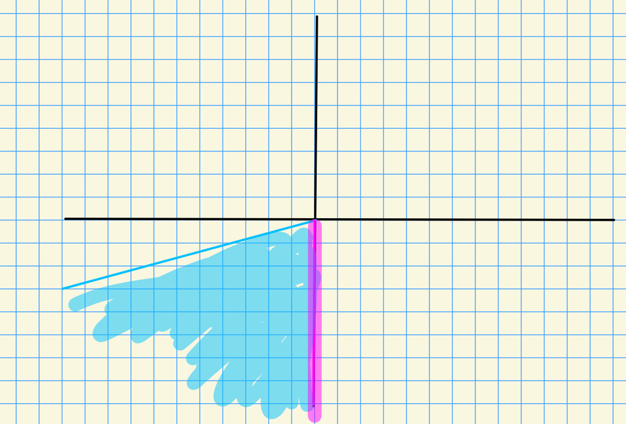

We know the axis:
$$\begin{align*}
H^j(F; \mu_m^{\otimes j}) \xrightarrow{\sim} {\mathsf{K}}^{\scriptstyle\mathrm{M}} _j(F)/m
.\end{align*}$$

Let $F\in \mathsf{Field}^{\operatorname{ch}= p}$, then

- ${\mathsf{K}}^{\scriptstyle\mathrm{M}} _j(F)$ and ${\mathsf{K}}_j(F)$ are $p{\hbox{-}}$torsionfree.
- ${\mathsf{K}}_j(F)/p \xhookleftarrow{} {\mathsf{K}}^{\scriptstyle\mathrm{M}} _j(F)/p \xhookrightarrow{\operatorname{dLog}} \Omega_F^j$

The $\operatorname{dLog}$ map is defined as
$$\begin{align*}
\operatorname{dLog}: {\mathsf{K}}^{\scriptstyle\mathrm{M}} _j(F) / p &\to \Omega_f^j \\
\bigotimes_{i} \alpha_i &\mapsto \bigwedge\nolimits_i {d \alpha_i \over \alpha_i}
,\end{align*}
and we write \(\Omega^j_{F, \log} \mathrel{\vcenter{:}}=\operatorname{im}\operatorname{dLog}\).$$

So the above theorem is about showing the injectivity of $\operatorname{dLog}$. What Geisser-Levine really prove is that
$$\begin{align*}
{\mathbb{Z}}_{ \mathrm{mot}} (j)(F)/p \xrightarrow{\sim} \Omega_{F, \log}^j[-j]
.\end{align*}
Thus the mod \(p\) Atiyah-Hirzebruch spectral sequence, just motivic cohomology lives along the axis
\begin{align*}
E_2^{i, j} =
\begin{cases}
\Omega_{F, \log}^{-j} & i=0
\\
0 & \text{else }
\end{cases}
\Rightarrow{\mathsf{K}}_{i-j}(F; {\mathbb{Z}}/p)
\end{align*}
and \({\mathsf{K}}_j(F)/p \xrightarrow{\sim} \Omega_{F, \log}^j\).$$

So life is much nicer in $p$ matching the characteristic! Some remarks:

- The isomorphism remains true with $F$ replaced any $F\in {\mathsf{Alg}}_{/ {{\mathbb{F}}_p}} ^{\mathrm{reg}, {\mathsf{loc}}, \mathrm{Noeth}}$:
  $$\begin{align*}
  {\mathsf{K}}_j(F)/p \xrightarrow{\sim} \Omega_{F, \log}^j
  .\end{align*}$$
- The hard part of the theorem is showing that mod $p$, there is a surjection ${\mathsf{K}}^{\scriptstyle\mathrm{M}} _j(F) \twoheadrightarrow{\mathsf{K}}_j(F)$. The proof goes through using $z^j(F, \bullet)$ and the Atiyah-Hirzebruch spectral sequence, and seems to necessarily go through motivic cohomology.

Is there a direct proof? Or can one even just show that
$$\begin{align*}
{\mathsf{K}}_j(F)/p = 0 \text{ for } j> [F: {\mathbb{F}}_p]_{\mathrm{tr}}
?\end{align*}$$

This becomes an isomorphism after tensoring to ${\mathbb{Q}}$, so
$$\begin{align*}
{\mathsf{K}}^{\scriptstyle\mathrm{M}} _j(F) \otimes_{\mathbb{Z}}{\mathbb{Q}}\xrightarrow{\sim} {\mathsf{K}}_j(F)\otimes_{\mathbb{Z}}{\mathbb{Q}}
.\end{align*}
This is known to be true for finite fields.$$

$$\begin{align*}
H_{ \mathrm{mot}} ^i(F; Z(j)) \text{ is torsion unless }i=j
.\end{align*}
This is wide open, and would follow from the following:$$

If $X\in {\mathsf{sm}}{\mathsf{Var}}^{\mathop{\mathrm{proj}}}_{/ {k}}$ over $k$ a finite field, then
$$\begin{align*}
H_{ \mathrm{mot}} ^i(X; Z(j)) \text{ is torsion unless } i=2j
.\end{align*}$$

## 2.2 Variants on a theme

What things (other than ${\mathsf{K}}{\hbox{-}}$theory) can be motivically refined?

### 2.2.1 ${\mathsf{G}}{\hbox{-}}$theory

Bloch’s complex $z^j(X, \bullet)$ makes sense for any $X\in {\mathsf{Sch}}$, and for $X$ finite type over $R$ a field or a Dedekind domain. Its homology yields an Atiyah-Hirzebruch spectral sequence
$$\begin{align*}
E_2^{i, j} = {\operatorname{CH}}^{-j}(X, -i-j) \Rightarrow{\mathsf{G}}_{-i-j}(X)
,\end{align*}
where \({\mathsf{G}}{\hbox{-}}\)theory is the \({\mathsf{K}}{\hbox{-}}\)theory of \({\mathsf{Coh}}(X)\). See Levine’s work.$$

Then $z^j(X, \bullet)$ defines **motivic Borel-Moore homology**[^1] which refines ${\mathsf{G}}{\hbox{-}}$theory.

### 2.2.2 ${\mathsf{K}}^{\scriptscriptstyle \mathrm{H}} {\hbox{-}}$theory

This is Weibel’s “homotopy invariant ${\mathsf{K}}{\hbox{-}}$theory,” obtained by forcing homotopy invariance in a universal way, which satisfies
$$\begin{align*}
{\mathsf{K}}^{\scriptscriptstyle \mathrm{H}} (R[T]) \xrightarrow{\sim} {\mathsf{K}}^{\scriptscriptstyle \mathrm{H}} (R) && \forall R
.\end{align*}
One defines this as a simplicial spectrum
\begin{align*}
{\mathsf{K}}^{\scriptscriptstyle \mathrm{H}} (R) \mathrel{\vcenter{:}}={ {\left\lvert {
q \mapsto {\mathsf{K}}\qty{R[T_0, \cdots, T_q] \over 1 - \sum_{i=0}^q T_i}
} \right\rvert} }
.\end{align*}$$

One hopes that for (reasonable) schemes $X$, there should exist an ${\mathbb{A}}^1{\hbox{-}}$invariant motivic cohomology such that

- There is an Atiyah-Hirzebruch spectral sequence converging to ${\mathsf{K}}^{\scriptscriptstyle \mathrm{H}} _{i-j}(X)$.
- Some Beilinson-Lichtenbaum properties.
- Some relation to cycles.

For $X$ Noetherian with $\operatorname{krulldim}X<\infty$, the state-of-the-art is that stable homotopy machinery can produce an Atiyah-Hirzebruch spectral sequence using representability of ${\mathsf{K}}^{\scriptscriptstyle \mathrm{H}}$ in ${\mathsf{SH}}(X)$ along with the slice filtration.

### 2.2.3 Motivic cohomology with modulus

Let $X\in{\mathsf{sm}}{\mathsf{Var}}$ and $D\hookrightarrow X$ an effective (not necessarily reduced) Cartier divisor – thought of where $X\setminus D$ is an open which is compactified after adding $D$. Then one constructs $z^j\qty{ {X\vert D }, \bullet}$ which are complexes of cycles in “good position” with respect to the boundary $D$.

There is an Atiyah-Hirzebruch spectral sequence \begin{align*} E_2^{i, j} = {\operatorname{CH}}^{j}\qty{ {X \vert D }, (-i-j) } \Rightarrow{\mathsf{K}}_{-i-j}(X, D) ,\end{align*} where the limiting term involves *relative $K{\hbox{-}}$groups*. So there is a motivic (i.e. cycle-theoretic) description of relative ${\mathsf{K}}{\hbox{-}}$theory.

## 2.3 Étale ${\mathsf{K}}{\hbox{-}}$theory

${\mathsf{K}}{\hbox{-}}$theory is simple étale-locally, at least away from the residue characteristic.

If $A \in{\mathsf{loc}}\mathsf{Ring}$ is strictly Henselian with residue field $k$ and $m \geq 1$ is prime to $\operatorname{ch}k$, then
$$\begin{align*}
{\mathsf{K}}_n(A; {\mathbb{Z}}/m) \xrightarrow{\sim} {\mathsf{K}}_n(k; {\mathbb{Z}}/m)
\xrightarrow{\sim}
\begin{cases}
\mu_m(k)^{\otimes{n\over 2}} & n \text{ even}
\\
0 & n \text{ odd}.
\end{cases}
\end{align*}$$

The problem is that ${\mathsf{K}}{\hbox{-}}$theory does *not* satisfy étale descent!
$$\begin{align*}
\text{For } B\in{ \mathsf{Gal}} \mathsf{Field}_{/ {A}} ^{\deg < \infty},
&&
K(B)^{h{ \mathsf{Gal}} \qty{B_{/ {A}} }} \not\cong K(A)
.\end{align*}$$

View ${\mathsf{K}}{\hbox{-}}$theory as a presheaf of spectra (in the sense of infinity sheaves), and define **étale ${\mathsf{K}}{\hbox{-}}$theory** $K^\text{ét}$ to be the universal modification of ${\mathsf{K}}{\hbox{-}}$theory to satisfy étale descent. This was considered by Thomason, Soulé, Friedlander.

Even better than ${\mathsf{K}}^\text{ét}$ is Clausen’s **Selmer ${\mathsf{K}}{\hbox{-}}$theory**, which does the right thing integrally. Up to subtle convergence issues, for any $X\in {\mathsf{Sch}}$ and $m$ prime to $\operatorname{ch}X$ (the characteristic of the residue field) one gets an Atiyah-Hirzebruch spectral sequence
$$\begin{align*}
E_2^{i, j} = H_\text{ét}^{i-j}(X; \mu_m^{\otimes-j}) \Rightarrow{\mathsf{K}}_{i-j}^{\text{ét}}(X; {\mathbb{Z}}/m)
.\end{align*}$$

Letting $F$ be a field and $m$ prime to $\operatorname{ch}F$, the spectral sequence looks as follows:

[figure not shown]

> Link to Diagram

The whole thing converges to ${\mathsf{K}}_{-i-j}^\text{ét}(F; {\mathbb{Z}}/m)$, and the sector conjecturally converges to ${\mathsf{K}}_{-i-j}(F; {\mathbb{Z}}/m)$ by the Beilinson-Lichtenbaum conjecture.

## 2.4 Recent Progress

We now focus on

- Étale ${\mathsf{K}}{\hbox{-}}$theory, ${\mathsf{K}}^\text{ét}$
- mod $p$ coefficients, even period
- $p{\hbox{-}}$adically complete rings

The last is not a major restriction, since there is an arithmetic gluing square

[figure not shown]

> [Link to Diagram](https://q.uiver.app/?q=WzAsNCxbMCwwLCJSIl0sWzIsMCwiUlxcaW52ZXJ0e3B9Il0sWzIsMiwiXFxoYXR7Un1cXGludmVydHtwfSJdLFswLDIsIlxcaGF0e1J9Il0sWzAsM10sWzMsMl0sWzEsMl0sWzAsMV1d)

Here the bottom-left is the $p{\hbox{-}}$adic completion, and the right-hand side uses classical results when $p$ is prime to all residue characteristic classes.

For any $p{\hbox{-}}$adically complete ring $R$ (or in more generality, derived $p{\hbox{-}}$complete simplicial rings) one can associate a theory of **$p{\hbox{-}}$adic étale motivic cohomology** – $p{\hbox{-}}$complete complexes ${\mathbb{Z}}_p(j)(R)$ for $j\geq 0$ satisfying an analog of the Beilinson-Lichtenbaum conjectures:

1. An Atiyah-Hirzebruch spectral sequence:
   $$\begin{align*}
   E_2^{i, j} = H^{i-j}({\mathbb{Z}}_p(j)(R)) \Rightarrow{\mathsf{K}}_{-i-j}^\text{ét}(R; {\mathbb{Z}}){ {}_{ \widehat{p} } }
   .\end{align*}$$
2. Known low weights:
   $$\begin{align*}
   {\mathbb{Z}}_p(0)(R) &\xrightarrow{\sim} {\mathbb{R}}\Gamma_\text{ét}(R; {\mathbb{Z}}_p) \\
   {\mathbb{Z}}_p(1)(R) &\xrightarrow{\sim} { \overbrace{{\mathbb{R}}\Gamma_\text{ét}(R; {\mathbb{G}}_m)}^{\widehat{\hspace{4em}}} } [-1]
   .\end{align*}$$
3. Range of support: ${\mathbb{Z}}_p(j)(R)$ is supported in degrees $d\leq j+1$, and even in degrees $d\leq n+1$ if the $R{\hbox{-}}$module $\Omega_{R/pR}^1$ is generated by $n'<n$ elements. It is supported in non-negative degrees if $R$ is **quasisyntomic**, which is a mild smoothness condition that holds in particular if $R$ is regular.
4. An analog of Nesterenko-Suslin: for $R \in {\mathsf{loc}}\mathsf{Ring}$,
   $$\begin{align*}
   { \widehat{{\mathsf{K}}}^{\scriptscriptstyle \mathrm{M}} _j(R)} \xrightarrow{\sim} H^j({\mathbb{Z}}_p(j)(R))
   ,\end{align*}
   where \(\widehat{{\mathsf{K}}}^{\scriptscriptstyle \mathrm{M}}\) is the “improved Milnor \({\mathsf{K}}{\hbox{-}}\)theory” of Gabber-Kerz.$$
5. Comparison to Geisser-Levine: if $R$ is smooth over a perfect characteristic $p$ field, then
   $$\begin{align*}
   {\mathbb{Z}}_p(j)(R)/p \xrightarrow{\sim} {\mathbb{R}}\Gamma_\text{ét}(\operatorname{Spec}R; \Omega_{\log}^j)[-j]
   ,\end{align*}
   where \([-j]\) is a right-shift.$$

It converges to $K^\text{ét}_{-i-j}(R;{\mathbb{Z}}/p)$. The 0-column is ${ \overbrace{ {\mathsf{K}}^{\scriptstyle\mathrm{M}} _{-j}(R)}^{\widehat{\hspace{4em}}} }$, and we understand the 1-column: we have
$$\begin{align*}
H^{j+1} \xrightarrow{\sim} \varprojlim_{r} \tilde v_r(j)(R)
.\end{align*}
where \(\tilde v_r(j)(R)\) are the mod \(p^r\) weight \(j\) Artin-Schreier obstruction. For example,
\begin{align*}
\tilde v_1(j)(R) \mathrel{\vcenter{:}}=
\operatorname{coker}\qty{
1- C^{-1}: \Omega^j_{R/pR} \to {\Omega^j_{R/pR} \over {{\partial}}\Omega^{j-1}_{R/pR}}
}
= { R \over pR + \left\{{ a^p-a {~\mathrel{\Big|}~}a\in R }\right\} }
.\end{align*}
These are weird terms that capture some class field theory and are related to the Tate and Kato conjectures.$$

If $R$ is local, then the 3rd quadrant of the above spectral sequence gives an Atiyah-Hirzebruch spectral sequence converging to ${\mathsf{K}}_{-i-j}(R; {\mathbb{Z}}_p)$.

So we get things describing étale ${\mathsf{K}}{\hbox{-}}$theory, and after discarding a little bit we get something describing usual ${\mathsf{K}}{\hbox{-}}$theory. Moreover, for any local $p{\hbox{-}}$adically complete ring $R$, we have broken ${\mathsf{K}}_*(R; { {\mathbb{Z}}_p })$ into motivic pieces.

We same that for number fields, $\operatorname{cohdim}\leq 2$ yields a simple spectral sequence relating $K$ groups to Galois cohomology. Consider now a truncated polynomial algebra $A = k[T]/T^r$ for $k\in\mathsf{Perf}\mathsf{Field}^{\operatorname{ch}= p}$ and let $r\geq 1$. Then by the general bounds given in the theorem, $H^i(j) = 0$ unless $0\leq i \leq 2$, using that $\Omega$ can be generated by one element. Slightly more work will show $H^0, H^2$ vanish unless $i=j=0$ (so higher weights vanish), since they’re $p{\hbox{-}}$torsionfree and are killed by $p$.

So the spectral sequence collapses:

[figure not shown]

> Link to Diagram

So the Atiyah-Hirzebruch spectral sequence collapses to

$$\begin{align*}
{\mathsf{K}}_n\qty{ { K[T] \over \left\langle{T^r}\right\rangle }, \left\langle{T}\right\rangle}
=
\begin{cases}
H^1\qty{{\mathbb{Z}}_p\qty{n+1\over 2}} (R) & n \text{ odd}
\\
0 & n \text{ even}.
\end{cases}
.\end{align*}$$

When $r=2$, one can even valuation these nontrivial terms.

What is the motivic cohomology for regular schemes not over a field? We’d like to understand this in general.

# 3 Bibliography

[^1]: Note that this is homology and not cohomology!